# Median survival time

Ting Wu

2018-11-08

One parameter of interest in survival analysis is the median residual at time x.

Recall the definition of survival function, the probability of a subject experiencing the events beyond time x , defined as $S(x)=Pr (X >x) $, X is a continuous random variable.

In Kaplan Meier estimate, we find the smallest time $x_p$ for which the product limit estimator is less than or equal to 1-p. That is
$$\hat{X_p}= inf [ t: \hat{S} (t) \le 1-p ]$$

The LIFETEST procedure in SAS provides the survival time estimate in the table below:

[figure not shown]

```r
proc lifetest data=pbc outsurv=km_sur2
plots=survival( cl test atrisk (maxlen=13) nocensor) maxtime=4000 notable ;
time futime*status(0,1);
strata drug;
run;
```

In Kaplan Meier method, the estimator is appropriate only when the largest observation corresponds to a event. A Kaplan-Meier estimator is well defined for all event time points less than the largest observation time, and is NOT defined in other times. If the largest study time is a event , the survival curve is zero beyond this point. If the largest time point is censored the value of $S(t)$ beyond this point, the Kaplan Meier survival estimate is undetermined. These are the reasons that you may see the survival output data had missing estimators in those non-event times.

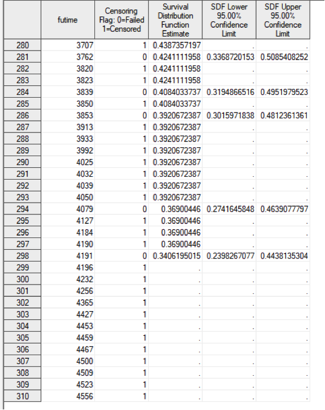